# Notebook

```python
import subprocess
import numpy as np
import matplotlib.pyplot as plt
import plumed
```

```python
# this is needed to avoid some random crash on MacOS
# see https://github.com/open-mpi/ompi/issues/6518
import os
os.environ["OMPI_MCA_btl"]="self,tcp"
```

```python
# we immediately import the wham tool and check it's from this directory
import wham
print(wham.__file__)
```

```
/Users/bussi/masterclass-21-5/wham.py
```

```python
# small utility to clean up backup files:
def clean():
    print(subprocess.run("rm -f \#*; rm -fr bck.*",shell=True))
# small utility to run with mpiexec
def run_mpi(cmd,nprocs=1):
    return subprocess.run("mpiexec -np {} --oversubscribe {}".format(nprocs,cmd),shell=True)
```

```python
# check if executables are in the path
! which plumed
! which gmx_mpi
```

```
/Users/bussi/.conda/envs/plumed-masterclass/bin/plumed
/Users/bussi/.conda/envs/plumed-masterclass/bin/gmx_mpi
```

```python
# clean up files produced in a previous run
! rm -fr us* be* colvar* pt* bck* plumed* traj*
```

## Exercise 1

In this exercise we perform a replica-exchange umbrella sampling simulation. We do it using a single plumed.dat file in the parent directory. We then prepare four base names for the four simulations

- start from A, without exchanges
- start from B, without exchanges
- start from A, with exchanges
- start from B, with exchanges

```python
at=np.linspace(-np.pi,np.pi,33)[:-1]
print(at)
for start in "A","B":
    for exchanges in "","x":
        with open("plumed_us_{}.dat".format(start+exchanges),"w") as f:
            print("""
        # vim:ft=plumed
        # since simulation run in subdir, we refer to a file in the parent dir:
        MOLINFO STRUCTURE=../reference.pdb
        phi: TORSION ATOMS=@phi-2
        psi: TORSION ATOMS=@psi-2
        bb: RESTRAINT ARG=phi KAPPA=200.0 AT=@replicas:{}
        # I am here writing files in the parent directory
        PRINT ARG=phi,psi,bb.bias FILE=../colvar_us_{}.dat STRIDE=100
        """.format(','.join(str(a) for a in at),start+exchanges),file=f)
        for i in range(len(at)):
            dd="us_"+start+exchanges+"_"+str(i)
            # we here copy the relevant files in the subdir
            subprocess.run("rm -fr {} && mkdir {} && \
                            cp topol{}.tpr {}/topol.tpr".format(dd,dd,start,dd),shell=True)
```

```
[-3.14159265 -2.94524311 -2.74889357 -2.55254403 -2.35619449 -2.15984495
 -1.96349541 -1.76714587 -1.57079633 -1.37444679 -1.17809725 -0.9817477
 -0.78539816 -0.58904862 -0.39269908 -0.19634954  0.          0.19634954
  0.39269908  0.58904862  0.78539816  0.9817477   1.17809725  1.37444679
  1.57079633  1.76714587  1.96349541  2.15984495  2.35619449  2.55254403
  2.74889357  2.94524311]
```

```python
# run the four simulations
for start in "A","B":
    for exchanges in "","x":
        if exchanges == "x":
            replex="-replex 200"
        else:
            replex=""
        run_mpi("gmx_mpi mdrun -plumed ../plumed_us_{}.dat -nsteps 200000 -multidir us_{}_? us_{}_?? {}".format(start+exchanges,start+exchanges,start+exchanges,replex),32)
```

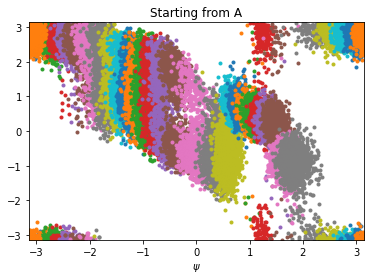

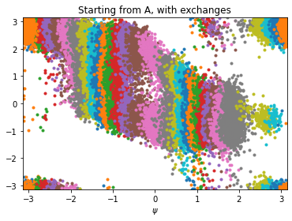

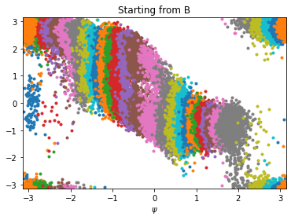

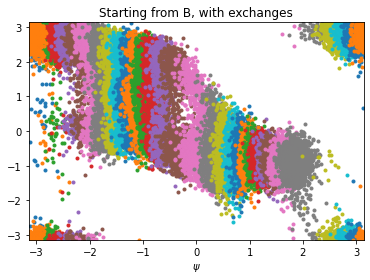

```python
# plot the trajectories for the 4 simulations
for start in "A","B":
    for exchanges in "","x":
        for i in range(32):
            title="Starting from "+start
            if exchanges == "x":
                title+=", with exchanges"
            plt.title(title)
            col=plumed.read_as_pandas("colvar_us_{}.{}.dat".format(start+exchanges,i))
            plt.plot(col.phi,col.psi,".")
            plt.xlabel("$\phi$")
            plt.xlabel("$\psi$")
            plt.xlim((-np.pi,+np.pi))
            plt.ylim((-np.pi,+np.pi))
        plt.show()
```

```python
# we then concatenate all the trajectories (for each of the four runs)
for start in "A","B":
    for exchanges in "","x":
        subprocess.run(
            "gmx_mpi trjcat -cat -f us_{}_?/traj_comp.xtc us_{}_??/traj_comp.xtc -o traj_us_{}.xtc".format(start+exchanges,start+exchanges,start+exchanges),
            shell=True)
```

```python
# and run the driver on the obtained trajectories
clean()
for start in "A","B":
    for exchanges in "","x":
        with open("plumed_us_process_{}.dat".format(start+exchanges),"w") as f:
            print("""
        # vim:ft=plumed
        MOLINFO STRUCTURE=reference.pdb # now reference.pdb is in the running directory
        phi: TORSION ATOMS=@phi-2
        psi: TORSION ATOMS=@psi-2
        bb: RESTRAINT ARG=phi KAPPA=200.0 AT=@replicas:{}
        # I am here writing files in the parent directory
        PRINT ARG=phi,psi,bb.bias FILE=colvar_us_process_{}.dat STRIDE=100 # now colvar is in the running directory
        """.format(','.join(str(a) for a in at),start+exchanges),file=f)
        run_mpi("plumed driver --multi 32 --plumed plumed_us_process_{}.dat --ixtc traj_us_{}.xtc --trajectory-stride=100".format(start+exchanges,start+exchanges),32)
```

```
CompletedProcess(args='rm -f \\#*; rm -fr bck.*', returncode=0)
```

```python
# we read the four resulting colvars with pandas
colvar_A=[]
colvar_Ax=[]
colvar_B=[]
colvar_Bx=[]
for i in range(32):
    colvar_A.append(plumed.read_as_pandas("colvar_us_process_A.{}.dat".format(i)))
    colvar_Ax.append(plumed.read_as_pandas("colvar_us_process_Ax.{}.dat".format(i)))
    colvar_B.append(plumed.read_as_pandas("colvar_us_process_B.{}.dat".format(i)))
    colvar_Bx.append(plumed.read_as_pandas("colvar_us_process_Bx.{}.dat".format(i)))
```

```python
def analyze(traj):
    kb=0.008314462618
    T=300
    bias=np.zeros((len(traj[0]["bb.bias"]),32))
    for i in range(32):
        bias[:,i]=traj[i]["bb.bias"]
    w=wham.wham(bias,T=kb*T)
    tr=traj[0].phi[-len(bias):]
    is_in_B=np.int_(np.logical_and(tr>0,tr<2))
    is_in_A=np.int_(tr<0)
    return np.average(is_in_B,weights=np.exp(w["logW"]))/np.average(is_in_A,weights=np.exp(w["logW"]))
print("relative population (A)               :",analyze(colvar_A))
print("relative population (A with exchanges):",analyze(colvar_Ax))
print("relative population (B)               :",analyze(colvar_B))
print("relative population (B with exchanges):",analyze(colvar_Bx))
```

```
relative population (A)               : 0.0035809326113286676
relative population (A with exchanges): 0.030813059866354995
relative population (B)               : 0.015909491115979803
relative population (B with exchanges): 0.02381113120031632
```

When not doing exchanges, the dependence of the result on the initial state is large. When doing exchanges, dependence is less.

## Exercise 2

```python
# We now analyze the md.log to track exchanges.
# This is for the run starting from A
!demux.pl us_Ax_0/md.log
replica_tempA=np.loadtxt("replica_temp.xvg")
```

```
-----------------------------------------------------------------
Going to read a file containing the exchange information from
your mdrun log file (us_Ax_0/md.log).
This will produce a file (replica_index.xvg) suitable for
demultiplexing your trajectories using trjcat,
as well as a replica temperature file (replica_temp.xvg).
Each entry in the log file will be copied 0 times.
-----------------------------------------------------------------
There are 32 replicas.
Finished writing replica_index.xvg and replica_temp.xvg with 1000 lines
```

```python
# and this is for the run starting from B
!demux.pl us_Bx_0/md.log
replica_tempB=np.loadtxt("replica_temp.xvg")
```

```
-----------------------------------------------------------------
Going to read a file containing the exchange information from
your mdrun log file (us_Bx_0/md.log).
This will produce a file (replica_index.xvg) suitable for
demultiplexing your trajectories using trjcat,
as well as a replica temperature file (replica_temp.xvg).
Each entry in the log file will be copied 0 times.
-----------------------------------------------------------------
There are 32 replicas.
Finished writing replica_index.xvg and replica_temp.xvg with 1000 lines
```

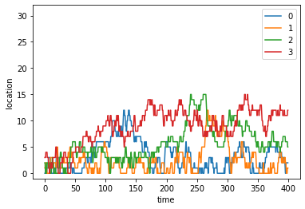

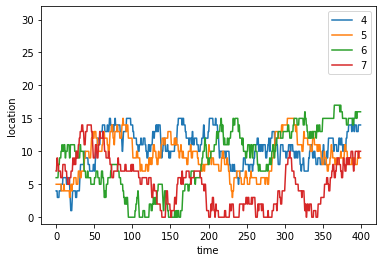

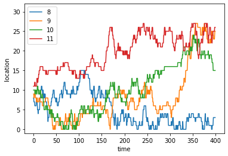

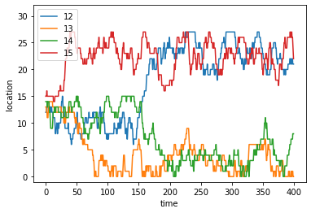

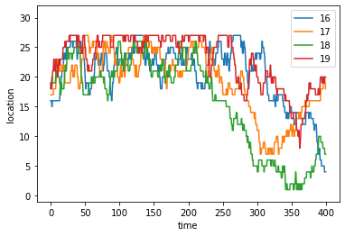

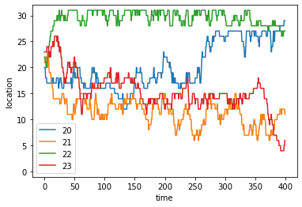

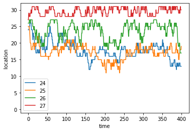

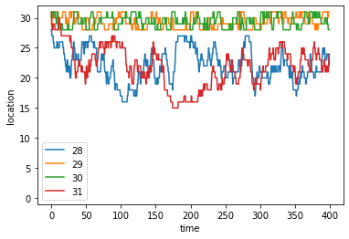

```python
# trajectories in replica space for run A
# four replicas per plot to avoid crowding
for i in range(32):
    plt.plot(replica_tempA[:,0],replica_tempA[:,i+1],label=str(i))
    if (i+1)%4==0:
        plt.xlabel("time")
        plt.ylabel("location")
        plt.ylim((-1,32))
        plt.legend()
        plt.show()
```

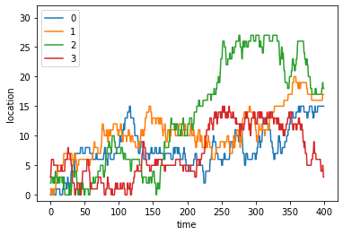

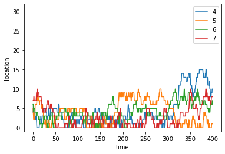

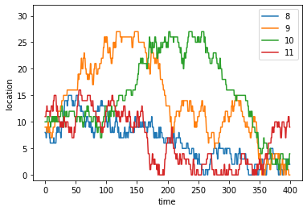

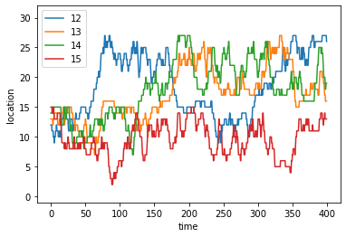

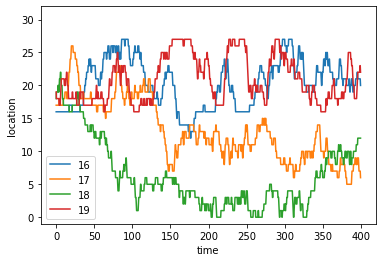

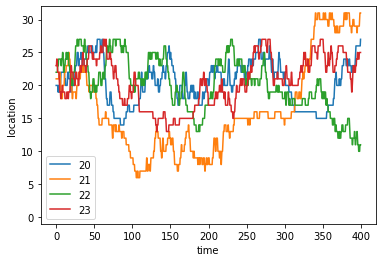

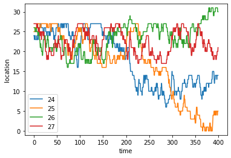

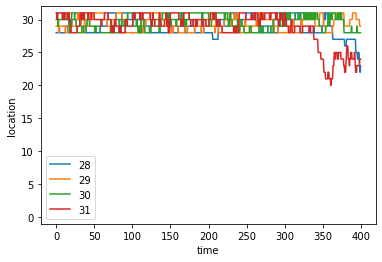

```python
# trajectories in replica space for run B
for i in range(32):
    plt.plot(replica_tempB[:,0],replica_tempB[:,i+1],label=str(i))
    if (i+1)%4==0:
        plt.ylim((-1,32))
        plt.xlabel("time")
        plt.ylabel("location")
        plt.legend()
        plt.show()
```

Note that some replicas are diffusing whereas others are stuck. In general, you should not expect that every replica diffuses on the whole range (in the same way as you should not expect that if you cut your plain MD simulation in 32 consecutive block each block is identical to the others). However, you should expect several replicas spannning a significant range.

Also notice that replicas with the 3 highest indexes are kind of separated from the others. In line of principle, for this system one should propose also exchanges between first and last replica. This would probably make these replicas join those with low indexes.

## Exercise 3

We now compute errors on the demuxed trajectories.

```python
# We first demux them and concatenate them
for start in "A","B":
    subprocess.run("demux.pl us_{}x_0/md.log".format(start),shell=True)
    subprocess.run("gmx_mpi trjcat -cat -f us_{}x_?/traj_comp.xtc us_{}x_??/traj_comp.xtc \
      -demux replica_index.xvg -o ".format(start,start)
        + ''.join([" "+str(i)+"_us_" + start + "x_trajout.xtc" for i in range(32)]),shell=True)
    subprocess.run(
            "gmx_mpi trjcat -cat -f ?_us_{}x_trajout.xtc ??_us_{}x_trajout.xtc -o traj_us_{}x_demux.xtc".format(start,start,start),
            shell=True)
```

```python
# Then process each of them with driver
clean()
for start in "A","B":
        with open("plumed_us_process_{}x.dat".format(start),"w") as f:
            print("""
        # vim:ft=plumed
        MOLINFO STRUCTURE=reference.pdb # now reference.pdb is in the running directory
        phi: TORSION ATOMS=@phi-2
        psi: TORSION ATOMS=@psi-2
        bb: RESTRAINT ARG=phi KAPPA=200.0 AT=@replicas:{}
        # I am here writing files in the parent directory
        PRINT ARG=phi,psi,bb.bias FILE=colvar_us_process_{}x.dat STRIDE=100 # now colvar is in the running directory
        """.format(','.join(str(a) for a in at),start),file=f)
        run_mpi("plumed driver --multi 32 --plumed plumed_us_process_{}.dat --ixtc traj_us_{}_demux.xtc --trajectory-stride=100".format(start+exchanges,start+exchanges),32)
```

```
CompletedProcess(args='rm -f \\#*; rm -fr bck.*', returncode=0)
```

```python
# Finally use bootstrap with 32 blocks
# This will take a while
kb=0.008314462618
T=300
for start in "A","B":
    if start=="A":
        replica_temp=replica_tempA
    else:
        replica_temp=replica_tempB
    bias=np.zeros((2001*32,32))
    for i in range(32):
        col=plumed.read_as_pandas("colvar_us_process_{}x.{}.dat".format(start,i))
        bias[:,i]=col["bb.bias"]
    w0=wham.wham(bias,T=kb*T)
    tr=col.phi
    is_in_B=np.int_(np.logical_and(tr>0,tr<2))
    is_in_A=np.int_(tr<0)
    print("Whole trajectory:",np.average(is_in_B,weights=np.exp(w0["logW"]))/np.average(is_in_A,weights=np.exp(w0["logW"])))

    pop=[]
    for i in range(200):
        c=np.random.choice(32,32)
        tr_w=np.zeros(32)
        for k in range(32):
            tr_w+=np.bincount(np.int_(replica_temp)[:,c[k]+1],minlength=32)
        w=wham.wham(bias.reshape((32,-1,32))[c].reshape((-1,32)),T=kb*T,traj_weight=tr_w)
        tr=np.array(col.phi).reshape((32,-1))[c].flatten()
        is_in_B=np.int_(np.logical_and(tr>0,tr<2))
        is_in_A=np.int_(tr<0)
        pop.append(np.average(is_in_B,weights=np.exp(w["logW"]))/np.average(is_in_A,weights=np.exp(w["logW"])))
        print("  iteration ",i,pop[-1])
    print("Bootstrap",np.average(pop),np.std(pop))
```

```
Whole trajectory: 0.030813059866353847
  iteration  0 0.022246083360080923
  iteration  1 0.029263194568668806
  iteration  2 0.024013998525983897
  iteration  3 0.0469419950109449
  iteration  4 0.045993241055819575
  iteration  5 0.03285780742121354
  iteration  6 0.02566095474409131
  iteration  7 0.037437862701170936
  iteration  8 0.03361807039293616
  iteration  9 0.025160589566975998
  iteration  10 0.04246285971259816
  iteration  11 0.029329880423211805
  iteration  12 0.03282477884550392
  iteration  13 0.03691018552987169
  iteration  14 0.044176651492841834
  iteration  15 0.0389795593220112
  iteration  16 0.028291379989854055
  iteration  17 0.029913514950071444
  iteration  18 0.022921848770042805
  iteration  19 0.039375692735926865
  iteration  20 0.03641706444827744
  iteration  21 0.02703770740137427
  iteration  22 0.020424146955629014
  iteration  23 0.03349019399815418
  iteration  24 0.019626089847226247
  iteration  25 0.03340399075179704
  iteration  26 0.03814430640237543
  iteration  27 0.033562028174838714
  iteration  28 0.02003932994973583
  iteration  29 0.0539537429549785
  iteration  30 0.03426376696078681
  iteration  31 0.02397629914573747
  iteration  32 0.017562368015530367
  iteration  33 0.024279524954544787
  iteration  34 0.0287809408809749
  iteration  35 0.027879690369026783
  iteration  36 0.027341258558098866
  iteration  37 0.04159605379504265
  iteration  38 0.021786382150275098
```

[output cut: 167 more lines]

```
  iteration  4 0.030881903751270506
  iteration  5 0.02725260319506698
  iteration  6 0.02558688947301811
  iteration  7 0.030266001981781466
  iteration  8 0.0220917091829583
  iteration  9 0.03472712470193543
  iteration  10 0.015769546900539572
  iteration  11 0.027703956107184166
  iteration  12 0.023269257204814455
  iteration  13 0.023543209326956676
  iteration  14 0.02150008303087667
  iteration  15 0.02449742910852241
  iteration  16 0.01693367865097542
  iteration  17 0.020845457157767443
  iteration  18 0.03702605972161254
```

```
  iteration  19 0.02731083697775596
  iteration  20 0.024923369089587356
  iteration  21 0.029821763415767578
  iteration  22 0.025865282254851588
  iteration  23 0.018359552467735504
  iteration  24 0.02447183039197247
  iteration  25 0.024107870230558055
  iteration  26 0.024908551636955985
  iteration  27 0.022745961654893558
  iteration  28 0.024020240752569248
  iteration  29 0.021824066427581855
  iteration  30 0.03403173554354676
  iteration  31 0.025609683792746
  iteration  32 0.02147074477064786
  iteration  33 0.033208583201287556
  iteration  34 0.03462270437689186
  iteration  35 0.022012478980228487
  iteration  36 0.02468289013368367
  iteration  37 0.020706108609881962
  iteration  38 0.021554715900899062
  iteration  39 0.028323084603549445
  iteration  40 0.024205214196012133
  iteration  41 0.023050951605123837
  iteration  42 0.016863380685992635
  iteration  43 0.03474613337752377
  iteration  44 0.027682934122367747
  iteration  45 0.019735297215881895
  iteration  46 0.02468116997335774
  iteration  47 0.01884547819691294
  iteration  48 0.01896437226940424
  iteration  49 0.033840987642880495
  iteration  50 0.03452097101621344
  iteration  51 0.025274933498769633
  iteration  52 0.022751228236958892
  iteration  53 0.035458204903964036
  iteration  54 0.021351018144935764
  iteration  55 0.03297328868216902
  iteration  56 0.030235729595773503
  iteration  57 0.021611994026123828
  iteration  58 0.018106210219853536
```

[output cut: 127 more lines]

```
  iteration  186 0.03213684402511668
  iteration  187 0.018949559938010667
  iteration  188 0.029508018342507793
  iteration  189 0.01357209533923922
  iteration  190 0.02351428306910456
  iteration  191 0.026823532310193316
  iteration  192 0.027249785591754675
  iteration  193 0.02184018403054976
  iteration  194 0.026964878497730504
  iteration  195 0.014359994824028659
  iteration  196 0.029827800478935785
  iteration  197 0.021321274109533977
  iteration  198 0.02460644894083736
  iteration  199 0.013751368555834056
Bootstrap 0.02524987530681517 0.005755786009162991
```

## Exercise 4

We now switch to bias-exchange metadynamics. At first we run without exchanges

```python
with open("plumed_be.dat","w") as f:
    print("""
# vim:ft=plumed
MOLINFO STRUCTURE=../reference.pdb
# this is needed to allow arbitrary pairs to try exchanges
# in this case, 0<->1, 0<->2, and 1<->2
RANDOM_EXCHANGES
phi: TORSION ATOMS=@phi-2
psi: TORSION ATOMS=@psi-2
# You can use the same parameters that you used in masterclass 21.4
m: METAD ...
   ARG=@replicas:phi,psi,phi
   SIGMA=0.3
   HEIGHT=@replicas:1.2,1.2,0.0 # make sure that there is no bias on the third replica!
   BIASFACTOR=8
   PACE=500
   GRID_MIN=-pi
   GRID_MAX=pi
   FILE=../HILLS_BE
...
PRINT ARG=phi,psi FILE=../colvar_be.dat STRIDE=100
""",file=f)
```

```python
# let's call the directory be, even though there are NO exchanges (no replex option)
for i in range(3):
    dd="be"+str(i)
    subprocess.run("rm -fr {} && mkdir {} && \
                    cp topolA.tpr {}/topol.tpr".format(dd,dd,dd),shell=True)

run_mpi("gmx_mpi mdrun -plumed \
  ../plumed_be.dat -nsteps 1000000 -multidir be?",3)
```

```
CompletedProcess(args='mpiexec -np 3 --oversubscribe gmx_mpi mdrun -plumed   ../plumed_be.dat -nsteps 1000000 -multidir be?', returncode=0)
```

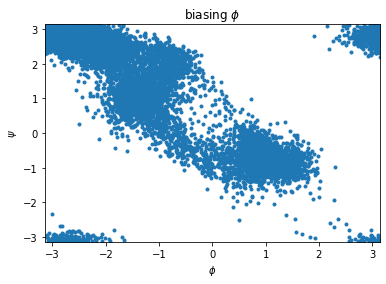

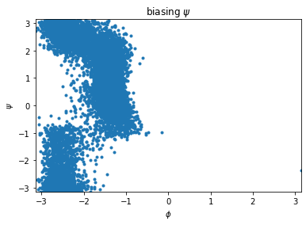

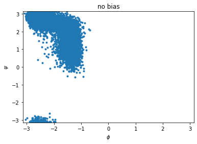

```python
# we then read the corresponding trajectories
be=[]
for i in range(3):
    if i==0:
        title="biasing $\phi$"
    elif i==1:
        title="biasing $\psi$"
    else:
        title="no bias"
    be.append(plumed.read_as_pandas("colvar_be.{}.dat".format(i)))
    plt.plot(be[-1].phi,be[-1].psi,".")
    plt.xlabel("$\phi$")
    plt.ylabel("$\psi$")
    plt.xlim((-np.pi,+np.pi))
    plt.ylim((-np.pi,+np.pi))
    plt.title(title)
    plt.show()
```

As expected, biasing $\psi$ does not allow sampling the second minimum.

We then run with exchanges

```python
with open("plumed_bex.dat","w") as f:
    print("""
# vim:ft=plumed
MOLINFO STRUCTURE=../reference.pdb
# this is needed to allow arbitrary pairs to try exchanges
# in this case, 0<->1, 0<->2, and 1<->2
RANDOM_EXCHANGES
phi: TORSION ATOMS=@phi-2
psi: TORSION ATOMS=@psi-2
# You can use the same parameters that you used in masterclass 21.4
m: METAD ...
   ARG=@replicas:phi,psi,phi
   SIGMA=0.3
   HEIGHT=@replicas:1.2,1.2,0.0 # make sure that there is no bias on the third replica!
   BIASFACTOR=8
   PACE=500
   GRID_MIN=-pi
   GRID_MAX=pi
   FILE=../HILLS_BEX
...
PRINT ARG=phi,psi FILE=../colvar_bex.dat STRIDE=100
""",file=f)
```

```python
for i in range(3):
    dd="bex"+str(i)
    subprocess.run("rm -fr {} && mkdir {} && \
                    cp topolA.tpr {}/topol.tpr".format(dd,dd,dd),shell=True)

run_mpi("gmx_mpi mdrun -plumed \
  ../plumed_bex.dat -nsteps 1000000 -multidir bex? -replex 200",3)
```

```
CompletedProcess(args='mpiexec -np 3 --oversubscribe gmx_mpi mdrun -plumed   ../plumed_bex.dat -nsteps 1000000 -multidir bex? -replex 200', returncode=0)
```

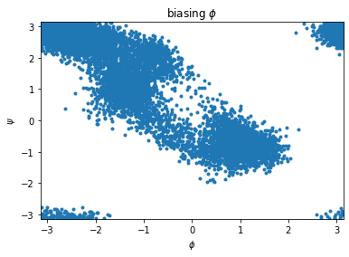

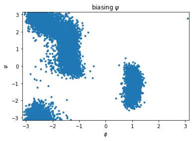

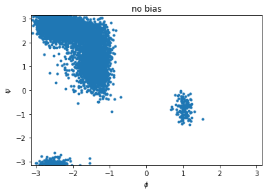

```python
bex=[]
for i in range(3):
    if i==0:
        title="biasing $\phi$"
    elif i==1:
        title="biasing $\psi$"
    else:
        title="no bias"
    bex.append(plumed.read_as_pandas("colvar_bex.{}.dat".format(i)))
    plt.plot(bex[-1].phi,bex[-1].psi,".")
    plt.xlabel("$\phi$")
    plt.ylabel("$\psi$")
    plt.xlim((-np.pi,+np.pi))
    plt.ylim((-np.pi,+np.pi))
    plt.title(title)
    plt.show()
```

Now all replicas can sample all minima, but with different populations. Clearly, transitions only happened in replica zero (the other replicas do not cross the transition state). The "neutral" replica was able to sample both states. This is happening since the less stable state is not too high in free energy. The replica biasing $\psi$ didn't sample very much the region at $\psi \approx -1$ and $\phi<0$. This is because this barrier was hidden by the metastable state at $\phi>0$. This didn't happen in the simulation without exchanges, because this latter state was not visited. Finally, notice that the simulation biasing $\phi$ did not differ much from the corresponding simulation without exchanges. This is because the other variable ($\psi$) was not of much help here. In more complicated cases, you can expect more than one replica to cooperatively help each other.

We then process the two trajectories

```python
with open("plumed_be_process.dat","w") as f:
    print("""
# vim:ft=plumed
MOLINFO STRUCTURE=reference.pdb
# this is needed to allow arbitrary pairs to try exchanges
# in this case, 0<->1, 0<->2, and 1<->2
RANDOM_EXCHANGES
phi: TORSION ATOMS=@phi-2
psi: TORSION ATOMS=@psi-2
# You can use the same parameters that you used in masterclass 21.4
m: METAD ...
   ARG=@replicas:phi,psi,phi
   SIGMA=0.3
   HEIGHT=0.0 # make sure that there is no bias on the third replica!
   BIASFACTOR=8
   PACE=50000000
   GRID_MIN=-pi
   GRID_MAX=pi
   FILE=HILLS_BE
   RESTART=YES
...
PRINT ARG=phi,psi,m.bias FILE=colvar_be_process.dat STRIDE=100
""",file=f)

with open("plumed_bex_process.dat","w") as f:
    print("""
# vim:ft=plumed
MOLINFO STRUCTURE=reference.pdb
# this is needed to allow arbitrary pairs to try exchanges
# in this case, 0<->1, 0<->2, and 1<->2
RANDOM_EXCHANGES
phi: TORSION ATOMS=@phi-2
psi: TORSION ATOMS=@psi-2
# You can use the same parameters that you used in masterclass 21.4
m: METAD ...
   ARG=@replicas:phi,psi,phi
   SIGMA=0.3
   HEIGHT=0.0 # make sure that there is no bias on the third replica!
   BIASFACTOR=8
   PACE=50000000
   GRID_MIN=-pi
   GRID_MAX=pi
   FILE=HILLS_BEX
   RESTART=YES
...
PRINT ARG=phi,psi,m.bias FILE=colvar_bex_process.dat STRIDE=100
""",file=f)
```

```python
subprocess.run("gmx_mpi trjcat -cat -f be?/traj_comp.xtc -o traj_be.xtc",shell=True)
subprocess.run("gmx_mpi trjcat -cat -f bex?/traj_comp.xtc -o traj_bex.xtc",shell=True)
```

```
CompletedProcess(args='gmx_mpi trjcat -cat -f bex?/traj_comp.xtc -o traj_bex.xtc', returncode=0)
```

```python
kb=0.008314462618
T=300
run_mpi("plumed driver --multi 3 --kt {} --plumed plumed_be_process.dat --trajectory-stride 100 --ixtc traj_be.xtc".format(kb*T),3)
run_mpi("plumed driver --multi 3 --kt {} --plumed plumed_bex_process.dat --trajectory-stride 100 --ixtc traj_bex.xtc".format(kb*T),3)
```

```
CompletedProcess(args='mpiexec -np 3 --oversubscribe plumed driver --multi 3 --kt 2.4943387854 --plumed plumed_bex_process.dat --trajectory-stride 100 --ixtc traj_bex.xtc', returncode=0)
```

```python
be=[]
bex=[]
for i in range(3):
    be.append(plumed.read_as_pandas("colvar_be_process.{}.dat".format(i)))
    bex.append(plumed.read_as_pandas("colvar_bex_process.{}.dat".format(i)))
```

```python
def analyze(traj):
    kb=0.008314462618
    T=300
    bias=np.zeros((len(traj[0]["m.bias"]),3))
    for i in range(3):
        bias[:,i]=traj[i]["m.bias"]
    w=wham.wham(bias,T=kb*T)
    tr=traj[0].phi[-len(bias):]
    is_in_B=np.int_(np.logical_and(tr>0,tr<2))
    is_in_A=np.int_(tr<0)
    return np.average(is_in_B,weights=np.exp(w["logW"]))/np.average(is_in_A,weights=np.exp(w["logW"]))
print("relative population (no exchanges)  :",analyze(be))
print("relative population (with exchanges):",analyze(bex))
```

```
relative population (no exchanges)  : 0.0009558562194537331
relative population (with exchanges): 0.025324473263561294
```

Note: the apparent population of the second state when NOT doing exchanges is much lower. The reason is that replicas 1 and 2, based on their bias potentials, were supposed to be able to go there. However, they didn't. This is a general issue when using WHAM: each of the replicas should have sampled all the relevant states (with that Hamiltonian). Clearly, exchanges help all replicas provided that at least one replica can cross each of the relevant barriers.

```python
tr=bex[0].phi[2*len(bex[0].phi)//3:] # last third is the neutral replica
is_in_B=np.int_(np.logical_and(tr>0,tr<2))
is_in_A=np.int_(tr<0)
print("relative population from neutral replica:",np.average(is_in_B)/np.average(is_in_A))
```

```
relative population from neutral replica: 0.013786112519006589
```

## Exercise 5

We now switch to parallel tempering metadynamics.

```python
import numpy as np
import re
T=np.geomspace(300,800,4)
for i in range(len(T)):
    with open("top/grompp.mdp") as f:
        l=f.read()
    with open("top/grompp{}.mdp".format(i),"w") as f:
        # if you use this script on your input files, make sure that 300 only appears
        # on the temperature line! or better replace it with a placeholder string such as __TEMP__
        print(re.sub("300",str(T[i]),l),file=f)
    subprocess.run("mkdir -p ptmetad_{}".format(i),shell=True)
    subprocess.run("mkdir -p pt_{}".format(i),shell=True)
    # we will initialize some replica in A and some replica in B
    if i%2==0:
        conf="A"
    else:
        conf="B"
    # we use -maxwarn 1 here since the grompp file has been adapted from an old gromacs version.
    # in general, only use this option after you have understood that the warning is harmless
    subprocess.run("cd top/; gmx_mpi grompp -f grompp{}.mdp -c conf{}.gro -maxwarn 1 -o ../ptmetad_{}/topol.tpr".format(i,conf,i), shell=True)
    subprocess.run("cd top/; gmx_mpi grompp -f grompp{}.mdp -c conf{}.gro -maxwarn 1 -o ../pt_{}/topol.tpr".format(i,conf,i), shell=True)
```

```python
# at first we run without metad (only pt)
run_mpi("gmx_mpi mdrun -replex 200 -multidir pt_? -nsteps 1000000",4)
```

```
CompletedProcess(args='mpiexec -np 4 --oversubscribe gmx_mpi mdrun -replex 200 -multidir pt_? -nsteps 1000000', returncode=0)
```

```python
with open("plumed_ptmetad.dat","w") as f:
    print("""
# vim:ft=plumed
MOLINFO STRUCTURE=../reference.pdb
phi: TORSION ATOMS=@phi-2
psi: TORSION ATOMS=@psi-2
# You can use the same parameters that you used in masterclass 21.4
m: METAD ...
   ARG=psi
   SIGMA=0.3
   HEIGHT=1.2
   BIASFACTOR=8
   PACE=500
   GRID_MIN=-pi
   GRID_MAX=pi
   FILE=../HILLS_PTMETAD
...
PRINT ARG=phi,psi FILE=../colvar_ptmetad.dat STRIDE=100
""",file=f)
```

```python
# we then run with metad as well
# notice that we are biasing the "bad CV" (psi)!!!
run_mpi("gmx_mpi mdrun -replex 200 -multidir ptmetad_? -plumed ../plumed_ptmetad.dat -nsteps 1000000",4)
```

```
CompletedProcess(args='mpiexec -np 4 --oversubscribe gmx_mpi mdrun -replex 200 -multidir ptmetad_? -plumed ../plumed_ptmetad.dat -nsteps 1000000', returncode=0)
```

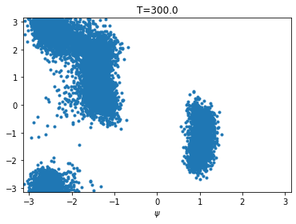

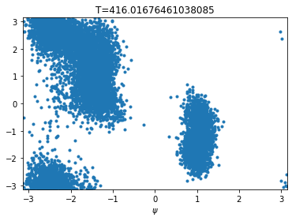

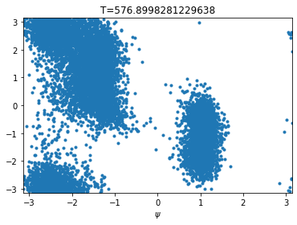

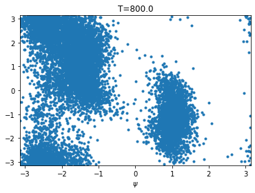

```python
# Here are the trajectories for pt+metad
for i in range(4):
    col=plumed.read_as_pandas("colvar_ptmetad.{}.dat".format(i))
    plt.plot(col.phi,col.psi,".")
    plt.xlim((-np.pi,+np.pi))
    plt.ylim((-np.pi,+np.pi))
    plt.xlabel("$\phi$")
    plt.xlabel("$\psi$")
    plt.title("T="+str(T[i]))
    plt.show()
```

```python
# We process the room temperature pt trajectory
with open("plumed_pt_process.dat","w") as f:
    print("""
# vim:ft=plumed
MOLINFO STRUCTURE=reference.pdb
phi: TORSION ATOMS=@phi-2
psi: TORSION ATOMS=@psi-2

PRINT ARG=phi,psi FILE=colvar_pt.dat STRIDE=100
""",file=f)
subprocess.run("plumed driver --plumed plumed_pt_process.dat --ixtc pt_0/traj_comp.xtc --trajectory-stride=100",shell=True)
```

```
CompletedProcess(args='plumed driver --plumed plumed_pt_process.dat --ixtc pt_0/traj_comp.xtc --trajectory-stride=100', returncode=0)
```

```python
# We then process the room temperature ptmetad trajectory
with open("plumed_ptmetad_process.dat","w") as f:
    print("""
# vim:ft=plumed
MOLINFO STRUCTURE=reference.pdb
phi: TORSION ATOMS=@phi-2
psi: TORSION ATOMS=@psi-2
m: METAD ...
   ARG=psi
   SIGMA=0.3
   HEIGHT=0.0
   BIASFACTOR=8
   PACE=5000000
   GRID_MIN=-pi
   GRID_MAX=pi
   FILE=HILLS_PTMETAD.0
   RESTART=YES
   TEMP=300
...
PRINT ARG=phi,psi,m.bias FILE=colvar_ptmetad.dat STRIDE=100
""",file=f)
subprocess.run("plumed driver --plumed plumed_ptmetad_process.dat --ixtc ptmetad_0/traj_comp.xtc --trajectory-stride 100",shell=True)
```

```
CompletedProcess(args='plumed driver --plumed plumed_ptmetad_process.dat --ixtc ptmetad_0/traj_comp.xtc --trajectory-stride 100', returncode=0)
```

```python
colvar_pt=plumed.read_as_pandas("colvar_pt.dat")
colvar_ptmetad=plumed.read_as_pandas("colvar_ptmetad.dat")
```

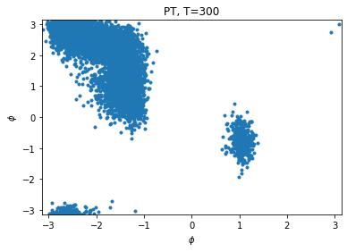

```python
plt.xlim((-np.pi,+np.pi))
plt.ylim((-np.pi,+np.pi))
plt.xlabel("$\phi$")
plt.ylabel("$\phi$")
plt.title("PT, T=300")
plt.plot(colvar_pt.phi,colvar_pt.psi,".")
```

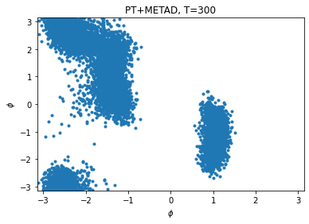

```python
plt.xlim((-np.pi,+np.pi))
plt.ylim((-np.pi,+np.pi))
plt.xlabel("$\phi$")
plt.ylabel("$\phi$")
plt.title("PT+METAD, T=300")
plt.plot(colvar_ptmetad.phi,colvar_ptmetad.psi,".")
```

```python
# population from pure pt
tr=colvar_pt.phi[:]
is_in_B=np.int_(np.logical_and(tr>0,tr<2))
is_in_A=np.int_(tr<0)
print("relative population (PT):",np.average(is_in_B)/np.average(is_in_A))
```

```
relative population (PT): 0.03950514606507954
```

```python
# population from ptmetad WITHOUT REWEIGHTING
# notice that this is not expected to be correct!!
tr=colvar_ptmetad.phi[:]
is_in_B=np.int_(np.logical_and(tr>0,tr<2))
is_in_A=np.int_(tr<0)
print("relative population:",np.average(is_in_B)/np.average(is_in_A))
# state B is visited much more than in pt
```

```
relative population: 0.3164407002764249
```

```python
# population from ptmetad WITH REWEIGHTING
# this is expected to be correct
tr=colvar_ptmetad.phi[:]
is_in_B=np.int_(np.logical_and(tr>0,tr<2))
is_in_A=np.int_(tr<0)
logW=+colvar_ptmetad["m.bias"]
logW-=np.max(logW)
logW/=kb*300
print("relative population:",np.average(is_in_B,weights=np.exp(logW))/np.average(is_in_A,weights=np.exp(logW)))
```

```
relative population: 0.014875271518731829
```

The latter case shows that if you have a variable that distinguishes approximately the metastable state but does not single out the transition state (such as $\psi$) it can be convenient to flatten its histogram in a PTMETAD simulation so as to have more sampling also in the less stable state. Having a more uniform simulated population of the two states will make the statistical error on their unbiased population smaller.